# Preliminary EDA

The primary dataset can be downloaded from the link, which is [here](https://github.com/Cassiebxy/STAT-184-Final-Project/tree/main)

```r
# Loading data
GlobalYouTube <- read.csv("/Users/cathybao/Desktop/GlobalYouTube.csv", header = TRUE)

library(ggplot2)
library(DataComputing)
library(Lock5Data)

data("GlobalInternet2019")
```

**Guiding Question:** In 2019 where are Youtuber channels most popular in the world, and does their internet speed play a role?

Where did we find the Data? *Kaggle*  
Who collected the data? *Nidula Elgiriyewithana*  
When and why? *It was updated 3 months ago, August 2023. It was collected to analyze and gain valuable insight from the platform.*  
What does a case represent and How many are there? *A case is one Youtube channel, and there are 995 cases.*  
What variables to do you plan to use? *Youtuber, Subscribers, Video Views, Longititude, Latitude, Created_year, and Country.*

```r
head(GlobalYouTube)
```

|  | V1 | V2 | V3 | V4 | V5 | V6 | V7 | V8 | V9 | V10 | V11 | V12 | V13 | V14 | V15 | V16 | V17 | V18 | V19 | V20 | V21 | V22 | V23 | V24 | V25 | V26 | V27 | V28 |
| --- | --- | --- | --- | --- | --- | --- | --- | --- | --- | --- | --- | --- | --- | --- | --- | --- | --- | --- | --- | --- | --- | --- | --- | --- | --- | --- | --- | --- |
| 1 | rank | Youtuber | subscribers | video views | category | Title | uploads | Country | Abbreviation | channel_type | video_views_rank | country_rank | channel_type_rank | video_views_for_the_last_30_days | lowest_monthly_earnings | highest_monthly_earnings | lowest_yearly_earnings | highest_yearly_earnings | subscribers_for_last_30_days | created_year | created_month | created_date | Gross tertiary education enrollment (%) | Population | Unemployment rate | Urban_population | Latitude | Longitude |
| 2 | 1 | T-Series | 245000000 | 2.28E+11 | Music | T-Series | 20082 | India | IN | Music | 1 | 1 | 1 | 2258000000 | 564600 | 9000000 | 6800000 | 108400000 | 2000000 | 2006 | Mar | 13 | 28.1 | 1366417754 | 5.36 | 471031528 | 20.593684 | 78.96288 |
| 3 | 2 | YouTube Movies | 170000000 | 0 | Film & Animation | youtubemovies | 1 | United States | US | Games | 4055159 | 7670 | 7423 | 12 | 0 | 0.05 | 0.04 | 0.58 | nan | 2006 | Mar | 5 | 88.2 | 328239523 | 14.7 | 270663028 | 37.09024 | -95.712891 |
| 4 | 3 | MrBeast | 166000000 | 28368841870 | Entertainment | MrBeast | 741 | United States | US | Entertainment | 48 | 1 | 1 | 1348000000 | 337000 | 5400000 | 4000000 | 64700000 | 8000000 | 2012 | Feb | 20 | 88.2 | 328239523 | 14.7 | 270663028 | 37.09024 | -95.712891 |
| 5 | 4 | Cocomelon - Nursery Rhymes | 162000000 | 1.64E+11 | Education | Cocomelon - Nursery Rhymes | 966 | United States | US | Education | 2 | 2 | 1 | 1975000000 | 493800 | 7900000 | 5900000 | 94800000 | 1000000 | 2006 | Sep | 1 | 88.2 | 328239523 | 14.7 | 270663028 | 37.09024 | -95.712891 |
| 6 | 5 | SET India | 159000000 | 1.48E+11 | Shows | SET India | 116536 | India | IN | Entertainment | 3 | 2 | 2 | 1824000000 | 455900 | 7300000 | 5500000 | 87500000 | 1000000 | 2006 | Sep | 20 | 28.1 | 1366417754 | 5.36 | 471031528 | 20.593684 | 78.96288 |

```r
head(GlobalInternet2019)
```

|  | Country | InternetSpeed | HoursOnline |
| --- | --- | --- | --- |
| 1 | Swizerland | 38.85 | 4.97 |
| 2 | United States | 32.89 | 6.52 |
| 3 | Germany | 24.64 | 4.62 |
| 4 | Australia | 16.36 | 5.07 |
| 5 | United Kingdom | 22.37 | 5.77 |
| 6 | France | 30.44 | 4.63 |

```r
library(dplyr)

colnames(GlobalYouTube)
```

```
 [1] "rank"                                    "Youtuber"
 [3] "subscribers"                             "video.views"
 [5] "category"                                "Title"
 [7] "uploads"                                 "Country"
 [9] "Abbreviation"                            "channel_type"
[11] "video_views_rank"                        "country_rank"
[13] "channel_type_rank"                       "video_views_for_the_last_30_days"
[15] "lowest_monthly_earnings"                 "highest_monthly_earnings"
[17] "lowest_yearly_earnings"                  "highest_yearly_earnings"
[19] "subscribers_for_last_30_days"            "created_year"
[21] "created_month"                           "created_date"
[23] "Gross.tertiary.education.enrollment...." "Population"
[25] "Unemployment.rate"                       "Urban_population"
[27] "Latitude"                                "Longitude"
```

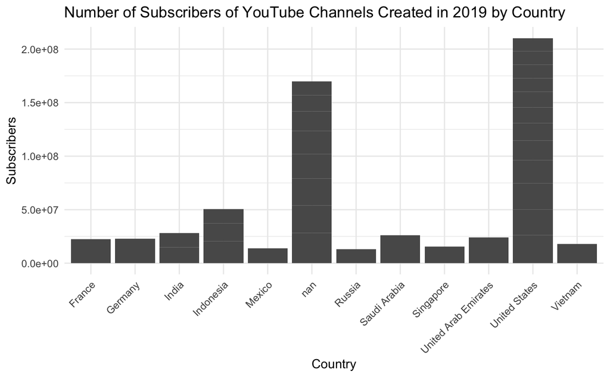

```r
GlobalYouTube %>%
  filter(created_year == 2019) %>%
  ggplot(aes(x = Country, y = subscribers)) +
  geom_bar(stat = "identity") +
  labs(title = "Number of Subscribers of YouTube Channels Created in 2019 by Country", x = "Country", y = "Subscribers") +
  theme_minimal() +
  theme(axis.text.x = element_text(angle = 45, hjust = 1))
```

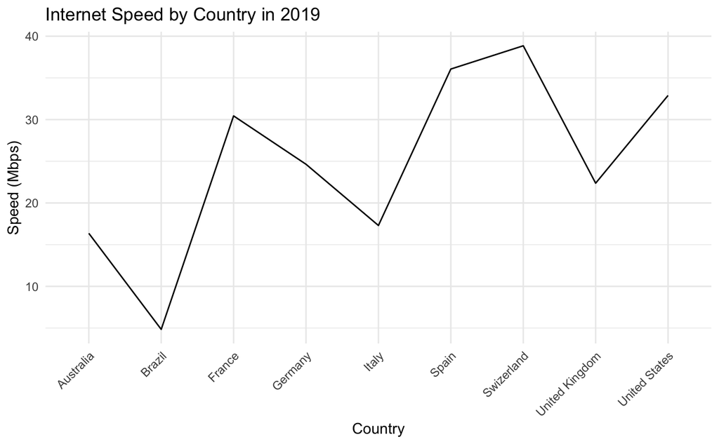

```r
GlobalInternet2019 %>%
  ggplot(aes(x = Country, y = InternetSpeed)) +
  geom_line(group = 1) +
  labs(title = "Internet Speed by Country in 2019", x = "Country", y = "Speed (Mbps)") +
  theme_minimal() +
  theme(axis.text.x = element_text(angle = 45, hjust = 1))
```

Based off the initial ranking of the data, it seems that the United States and India are home to the most popular Youtube Channels.

So based off of initial viewing of the data it appears that the United States will likely be one of the top places for popular Youtubers, and high internet speed.